# Analytic Plan Feb 2020

### Overall Considerations

In making sure my analyses for ACToday are optimized, I wanted to ask:

- What analyses are feasible within my limited time remaining with ACToday?
- What information would be most useful for the ACToday project, given its focus on climate services and policy change?

### Research Questions

1. Do extreme climate events increase prevalence of wasting among children in Bangladesh? a. If so, are there lags that are important to these relationships?

### Methodological Considerations

#### Case-Crossover Design

Case-crossover studies usually require (quoted from [Columbia Mailman SPH](https://www.mailman.columbia.edu/research/population-health-methods/case-crossover-design)):

- Short-term changes in exposure
- Transient changes in disease risk
- Acute-onset disease

My main questions with regards to our data:

- What is the time threshold at which disease risk becomes ‘transient’? Can we consider wasting, with a lag period of weeks to potentially months, transient?
- Similarly, there is uncertainty surrounding the actual ‘onset’ of wasting. Would it make sense to investigate these extreme events as ‘triggers’ that tip a child to acute malnutrition?
- Finally, in a case-crossover analysis of these data, would these potential lag structures interfere with our ability to select our case and control windows?

#### Log-Binomal Analysis of Cross-Sectional Data

Similar to our previous analyses, these would entail comparison of wasting prevalences across differing levels of exposure, adjusting for confounders. This would produce adjusted Prevalence Ratios.

Questions here:

- How do we investigate lags here - should it be a formal hypothesis testing process, or included in our exploratory analyses?
- We’ve been looking at extreme precipitation and temperature events, but less so at anomalously low values. Do we want to include these as well (e.g. drought)?

#### Other Methods

Have also considered:

- Distributed lag nonlinear models (DLNM)
  - What would this entail given our data structure?
- Time-series models (likely Poisson or quasi-Poisson regression?)
  - Not necessarily mapping acute exposure/outcome but overall
  - Could incorporate lags here
  - Could also consider season-stratified analyses

### Exploratory Analyses

Adjusted log-binomial models were run as follows (basic example code):

```r
logbin(
  data = data,
  formula = y ~ x +    ## substitute vector of lags for x
    surv_area + moy + year
)
```

Graphs of results, adjusted by year, month, and geographic region, are below.

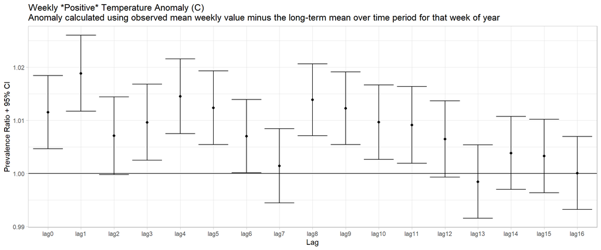

```r
test_results_adj2_t %>%
  mutate(
    beta1_df = as.ordered(beta1_df),
    time = 0:16,
    beta1_df = fct_reorder(beta1_df, time)) %>%
  ggplot(
    aes(x = beta1_df,
        y = exp(estimate),
        ymin = exp(lower),
        ymax = exp(upper))
  ) +
    geom_point() +
    geom_errorbar() +
    geom_hline(yintercept = 1) +
    theme_light() +
    labs(title = "Weekly *Positive* Temperature Anomaly (C)\nAnomaly calculated using observed mean weekly value minus the long-term mean over time period for that week of year",
         x = "Lag",
         y = "Prevalence Ratio + 95% CI")
```

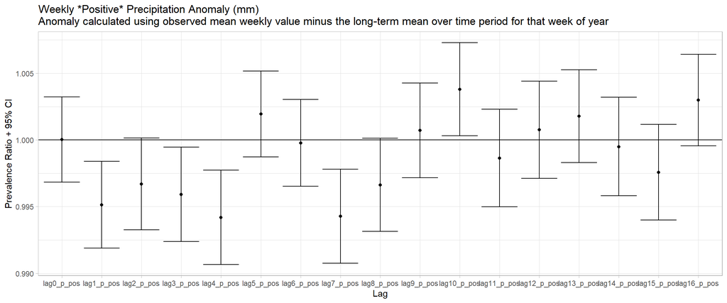

```r
test_results_adj_p_pos %>%
  mutate(
    beta1_df = as.ordered(beta1_df),
    time = 0:16,
    beta1_df = fct_reorder(beta1_df, time)) %>%
  ggplot(
    aes(x = beta1_df,
        y = exp(estimate),
        ymin = exp(lower),
        ymax = exp(upper))
  ) +
    geom_point() +
    geom_errorbar() +
    geom_hline(yintercept = 1) +
    theme_light() +
    labs(title = "Weekly *Positive* Precipitation Anomaly (mm)\nAnomaly calculated using observed mean weekly value minus the long-term mean over time period for that week of year",
         x = "Lag",
         y = "Prevalence Ratio + 95% CI")
```

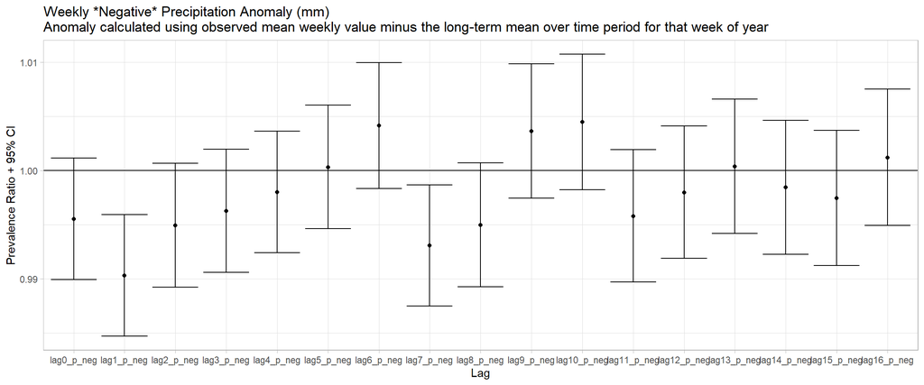

```r
test_results_adj_p_neg %>%
  mutate(
    beta1_df = as.ordered(beta1_df),
    time = 0:16,
    beta1_df = fct_reorder(beta1_df, time)) %>%
  ggplot(
    aes(x = beta1_df,
        y = exp(estimate),
        ymin = exp(lower),
        ymax = exp(upper))
  ) +
    geom_point() +
    geom_errorbar() +
    geom_hline(yintercept = 1) +
    theme_light() +
    labs(title = "Weekly *Negative* Precipitation Anomaly (mm)\nAnomaly calculated using observed mean weekly value minus the long-term mean over time period for that week of year",
         x = "Lag",
         y = "Prevalence Ratio + 95% CI")
```

Notes 02/12/2020

- Continue with **log-binomial** models
- What are plausible biological/other pathways that could lead to these lags?
  - High temperature
  - High precipitation
  - Low precipitation
- What is onset period of wasting, particularly with non-climate ex. in literature (e.g. onset of wasting after famine)?
- Operationalization of heat
- EM by
  - Season
  - Region
    - Politically actionable regions above survey area? –> district, level above district
- Self-notes
  - Spline functions for seasonal/long-term patterns
  - Interaction term / random effect? for region

*Next Steps*

- Literature searches:
  - Plausible pathways from climate exposures to wasting in children
  - Onset period of wasting from various insults (e.g. famine, non-climate but related)
- Consider exposure operationalizations
- Explore data:
  - Differential effects by region
  - Differential effects by season